# USL project - Fuel consumption

## Columns have data distributed across multiple scales. Several columns have distributions that are not unimodal (eg.: distance_circularity, hollows_ratio, elongatedness Column skweness_about, skewness_about 1 have data that is right skewed whereas for column skewness_about 2 data is nearly normally distributed

## Some columns have long right tail as evident from the above distplot it is highly likely that they will have outliers

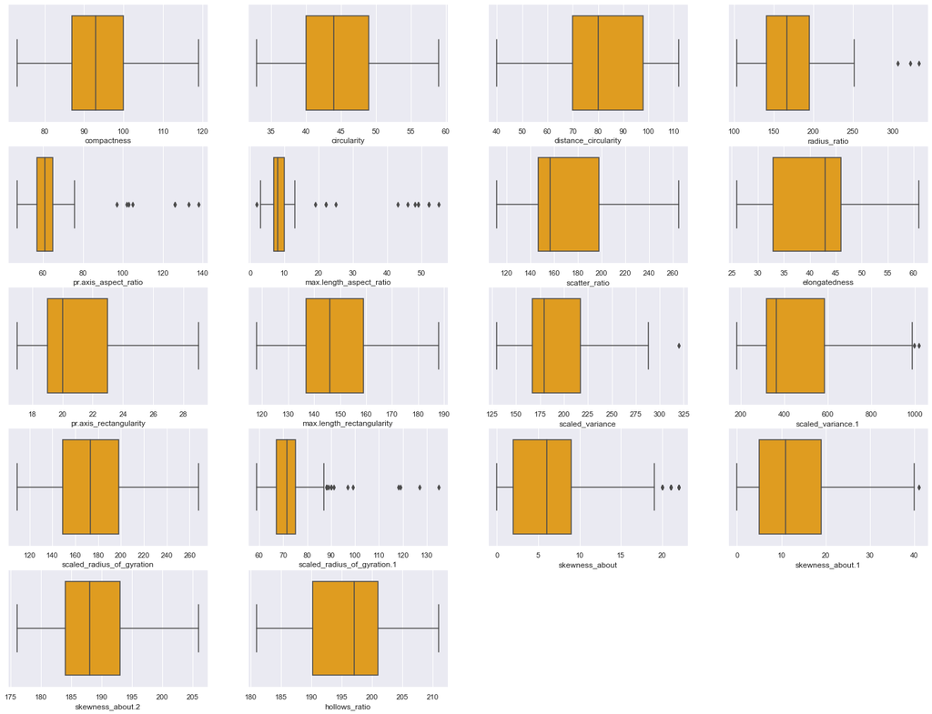

```python
#Checking for outliers

plt.figure(figsize = (25,23))
col = 1
for i in vehicle.drop(columns = 'class').columns:
    plt.subplot(6, 4, col)
    sns.boxplot(vehicle[i],color = 'orange')
    col += 1
```

## Outliers detected in multiple columns

```python
for col_name in vehicle.drop(columns = 'class').columns:
    q1 = vehicle[col_name].quantile(0.25)
    q3 = vehicle[col_name].quantile(0.75)
    iqr = q3 - q1

    low = q1 - 1.5 * iqr
    high = q3 + 1.5 * iqr

    vehicle.loc[(vehicle[col_name] < low) | (vehicle[col_name] > high), col_name] = vehicle[col_name].median()
```

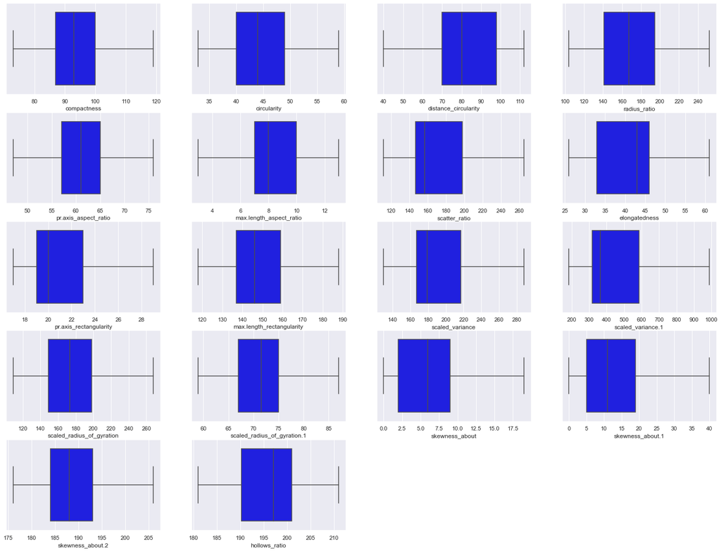

```python
#After outlier treatment

plt.figure(figsize = (25,23))
col = 1
for i in vehicle.drop(columns ='class').columns:
    plt.subplot(6, 4, col)
    sns.boxplot(vehicle[i],color ='blue')
    col += 1
```

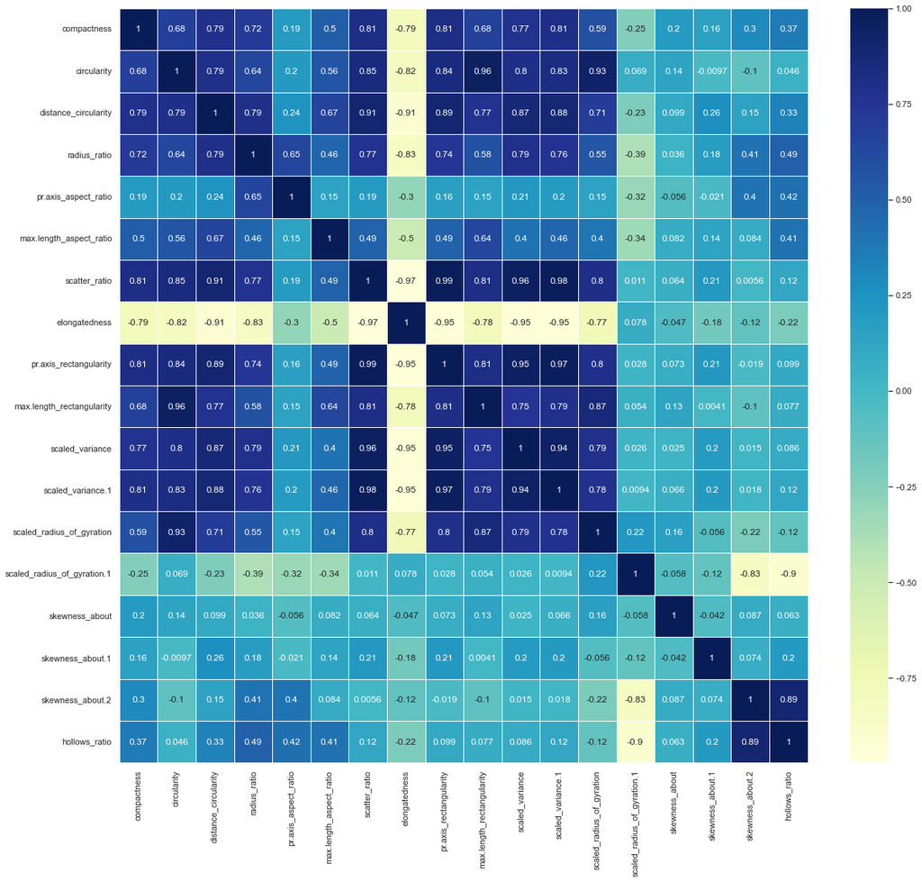

```python
#checking for correlation

plt.figure(figsize = (20,18))
corr = vehicle.corr()
sns.heatmap(corr,annot = True, linewidths=.5, cmap="YlGnBu");
```

```python
#splitting the data to check for correlation with the class variable

X = vehicle.loc[:, vehicle.columns != 'class']
y = vehicle['class'].astype('category').cat.codes
```

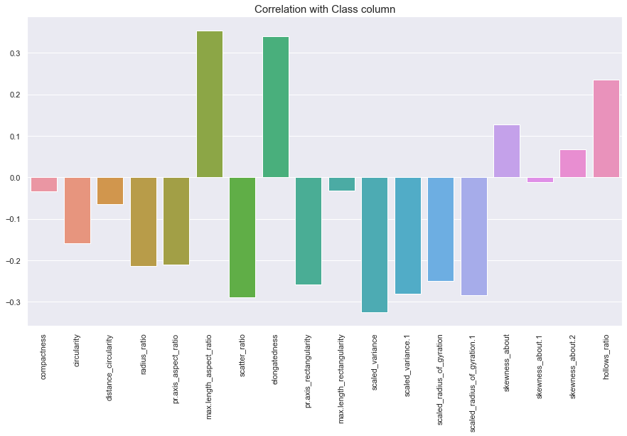

```python
#plotting the correlation with target variable

plt.figure(figsize = (15, 8))
ax = sns.barplot(x = X.columns, y = X.corrwith(y))
sns.barplot(x = X.columns, y = X.corrwith(y))

plt.title('Correlation with Class column', fontsize = 15)
x = plt.setp(ax.get_xticklabels(), rotation=90)
```

# PCA

```python
#scaling the numerical variables

XScaled = X.apply(zscore)
XScaled.head(10)
```

|  | compactness | circularity | distance_circularity | radius_ratio | pr.axis_aspect_ratio | max.length_aspect_ratio | scatter_ratio | elongatedness | pr.axis_rectangularity | max.length_rectangularity | scaled_variance | scaled_variance.1 | scaled_radius_of_gyration | scaled_radius_of_gyration.1 | skewness_about | skewness_about.1 | skewness_about.2 | hollows_ratio |
| --- | --- | --- | --- | --- | --- | --- | --- | --- | --- | --- | --- | --- | --- | --- | --- | --- | --- | --- |
| 0 | 0.160580 | 0.518073 | 0.057177 | 0.300945 | 1.933135 | 0.912212 | -0.207598 | 0.136262 | -0.224342 | 0.758332 | -0.400771 | -0.337407 | 0.285705 | -0.315806 | -0.032330 | 0.387162 | -0.312012 | 0.183957 |
| 1 | -0.325470 | -0.623732 | 0.120741 | -0.850666 | -0.740596 | 0.427456 | -0.599423 | 0.520519 | -0.610886 | -0.344578 | -0.594220 | -0.618623 | -0.513630 | 0.009122 | 0.624090 | 0.161740 | 0.013265 | 0.452977 |
| 2 | 1.254193 | 0.844303 | 1.519141 | 1.265808 | 0.863642 | 0.912212 | 1.148719 | -1.144597 | 0.935290 | 0.689401 | 1.114582 | 1.131806 | 1.392477 | 0.171586 | 1.718123 | -0.401818 | -0.149374 | 0.049447 |
| 3 | -0.082445 | -0.623732 | -0.006386 | -0.290423 | 0.328896 | 0.427456 | -0.750125 | 0.648605 | -0.610886 | -0.344578 | -0.916635 | -0.739145 | -1.466683 | -1.453054 | -0.032330 | -0.289106 | 1.639649 | 1.529056 |
| 4 | -1.054545 | -0.134387 | -0.769150 | 1.141310 | -0.027601 | -0.057300 | -0.599423 | 0.520519 | -0.610886 | -0.275646 | 1.694930 | -0.647319 | 0.408680 | -0.072110 | 0.624090 | -0.176395 | -1.450481 | -1.699181 |
| 5 | 1.618730 | -0.134387 | 1.519141 | 0.114197 | -1.988337 | -1.026812 | 2.595457 | -1.913112 | 2.868010 | 1.447652 | 2.952350 | 2.979800 | 2.745198 | 2.121153 | -0.251136 | -0.401818 | -1.287842 | -1.699181 |
| 6 | 0.403605 | -0.297502 | -0.578459 | 0.145322 | 0.685394 | -1.026812 | -0.478861 | 0.136262 | -0.610886 | -0.344578 | -0.400771 | -0.440711 | -0.083219 | -0.965662 | 1.499317 | -1.303509 | 1.802287 | 1.125526 |
| 7 | -0.446982 | -0.297502 | -1.023405 | -0.352672 | 0.685394 | 0.427456 | -0.961108 | 0.904777 | -0.997430 | -0.137782 | -0.852152 | -0.899840 | -0.329168 | -0.803198 | -0.688749 | -1.078086 | 0.663818 | 0.856507 |
| 8 | -0.933032 | -1.765536 | -1.277659 | -0.881791 | -0.027601 | -0.542056 | -1.413213 | 1.673292 | -1.383974 | -1.447489 | -1.529225 | -1.232708 | -1.927838 | -1.290590 | -0.907556 | 0.161740 | 1.802287 | 1.663566 |
| 9 | -0.082445 | -0.134387 | 1.010632 | -0.041426 | 0.150648 | 1.396968 | 0.425350 | -0.632254 | 0.548746 | -0.137782 | 0.437509 | 0.385721 | -0.698092 | -1.290590 | -0.469943 | 0.161740 | 0.989095 | 1.125526 |

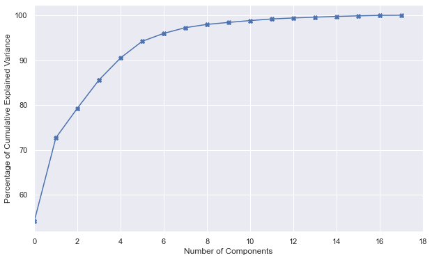

```python
#plotting the cumulative variance explained by the principal components

pca = PCA()
X_pca_ = pca.fit_transform(XScaled)
plt.figure(figsize = (10, 6))
plt.plot((np.cumsum(pca.explained_variance_ratio_) * 100), marker = 'X')
plt.xlim(0, 18)
plt.xlabel('Number of Components')
plt.ylabel('Percentage of Cumulative Explained Variance');
```

```python
print(pca.explained_variance_)
```

```
[9.74940269e+00 3.35071912e+00 1.19238155e+00 1.13381916e+00
 8.83997312e-01 6.66265745e-01 3.18150910e-01 2.28179142e-01
 1.31018595e-01 7.98619108e-02 7.33979478e-02 6.46162669e-02
 4.01448646e-02 3.22758478e-02 2.93936408e-02 2.27005257e-02
 1.98136761e-02 5.16287320e-03]
```

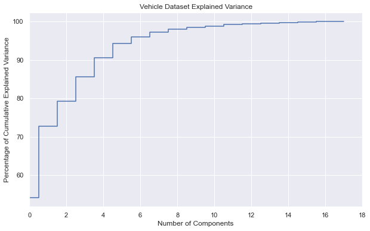

```python
plt.figure(figsize = (10, 6))
plt.step(list(range(18)), (np.cumsum(pca.explained_variance_ratio_) * 100), where = 'mid')
plt.xlim(0, 18)
plt.xlabel('Number of Components')
plt.ylabel('Percentage of Cumulative Explained Variance')
plt.title('Vehicle Dataset Explained Variance');
```

## The above plot shows almost 95% variance by the first 6 components. Therefore we can drop 7th component onwards.

```python
#Using 6 components and printing the eigen vectors

pca3 = PCA(n_components = 6)
pca3.fit(XScaled)
print(pca3.components_)
print(pca3.explained_variance_ratio_)
Xpca3 = pca3.transform(XScaled)
```

```
[[ 0.27250289  0.28725469  0.30242111  0.26971354  0.09786073  0.19520014
   0.31052393 -0.3090069   0.307287    0.27815416  0.29976509  0.30553237
   0.26323762 -0.04193594  0.03608321  0.05872048  0.03801314  0.08474   ]
 [-0.08704358  0.13162176 -0.04614301 -0.19793126 -0.25783995 -0.10804563
   0.07528535 -0.01322994  0.0875602   0.12215424  0.07726575  0.07150302
   0.21058205  0.50362158 -0.01576632 -0.09274624 -0.50162122 -0.50761211]
 [-0.03818521 -0.20114691  0.06346211  0.05628517 -0.06199275 -0.14895782
   0.10904283 -0.09085269  0.1060705  -0.21368469  0.1445998   0.11034374
  -0.20287019  0.07386402 -0.55917399  0.6706805  -0.06224071 -0.04170535]
 [ 0.13867501 -0.03805548  0.10895429 -0.25435509 -0.61276572  0.27867816
   0.00539295  0.06521486  0.03089915  0.04146747 -0.06400509 -0.00219687
  -0.08553965 -0.11539962  0.47370331  0.42842603 -0.0274096   0.09603749]
 [ 0.13710147 -0.13899555 -0.08001743  0.13374437  0.12360146 -0.63489336
   0.08555745 -0.07907344  0.08164638 -0.25111294  0.14747123  0.11010098
  -0.00521211  0.13806861  0.56655224  0.13086982  0.18051929 -0.11078807]
 [ 0.26361138 -0.07134743 -0.01690062 -0.13818365 -0.57782861 -0.289097
   0.09774711 -0.0757283   0.10540322 -0.07819621  0.1329124   0.11539822
  -0.0670574  -0.13151308 -0.31917609 -0.46840497  0.28013644  0.05944441]]
[0.54099325 0.18593103 0.06616512 0.0629155  0.04905291 0.03697101]
```

```python
#printing the original features and the reduced features

pca_6 = PCA(n_components = 6)
X_pca = pca_6.fit_transform(XScaled)
print('Original number of features:', X.shape[1])
print('Reduced number of features:', X_pca.shape[1])
```

```
Original number of features: 18
Reduced number of features: 6
```

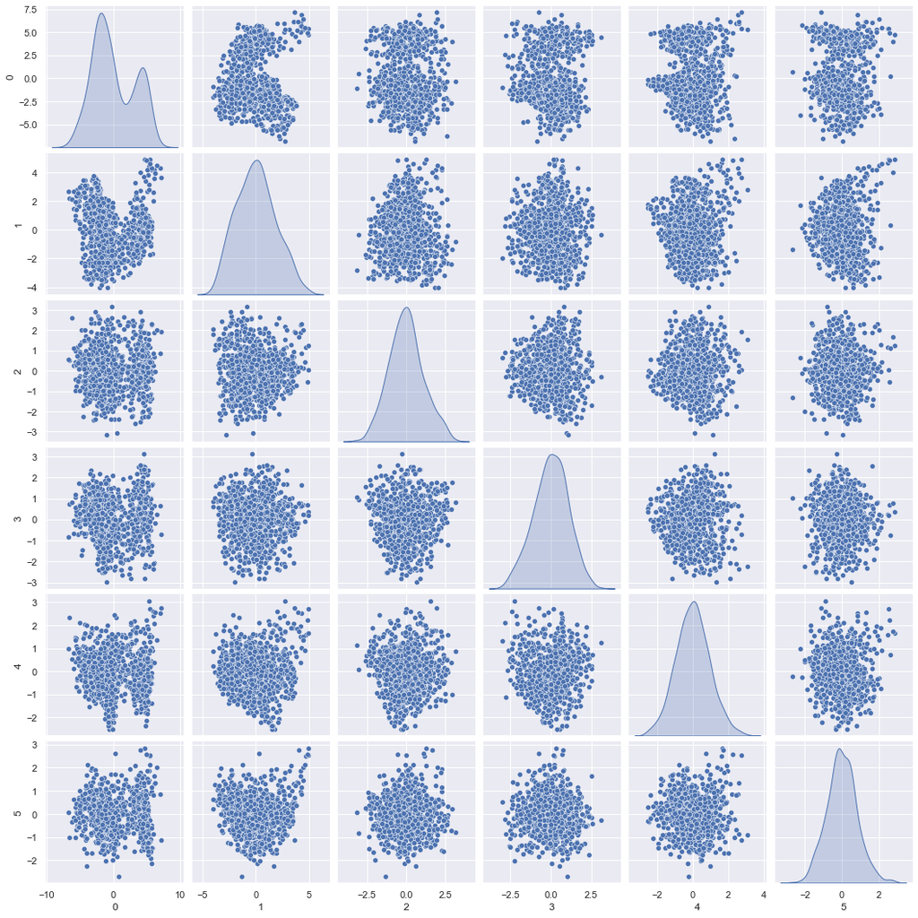

```python
# Pairplot

pca_df = pd.DataFrame(data = X_pca)
pca_df.head()
sns.pairplot(pca_df, diag_kind = 'kde');
```

## SVM on Original Dataset

```python
X_train, X_test, y_train, y_test = train_test_split(XScaled, y, test_size = 0.3, random_state = 42)
```

```python
# Building a Support Vector Machine on train data
svc_model = SVC(C = 4, kernel = 'rbf', gamma = 'scale')
svc_model.fit(X_train, y_train)
```

```
SVC(C=4)
```

```python
sv_train_predict = svc_model .predict(X_train)
print("Model Accuracy on train: {0:.4f}".format(metrics.accuracy_score(y_train, sv_train_predict)))
print()
```

```
Model Accuracy on train: 0.9916
```

```python
#predicting on test data

sv_test_predict = svc_model .predict(X_test)
print("Model Accuracy on test: {0:.4f}".format(metrics.accuracy_score(y_test, sv_test_predict)))
print()
```

```
Model Accuracy on test: 0.9843
```

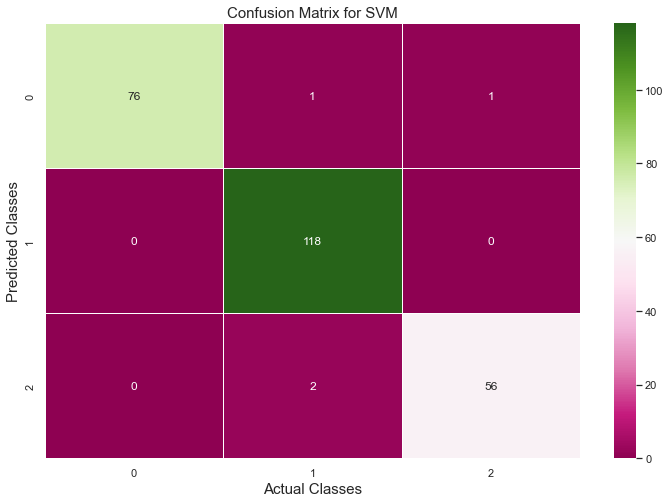

```python
#visualization of confusion matrix in the form of a heatmap

cm = confusion_matrix(y_test, sv_test_predict)
plt.figure(figsize = (12, 8))
sns.heatmap(cm, annot = True, cmap = 'PiYG', linewidths=.5, fmt = 'd')
plt.xlabel('Actual Classes', fontsize = 15)
plt.ylabel('Predicted Classes', fontsize = 15)
plt.title('Confusion Matrix for SVM', fontsize = 15);
```

```python
#printing classification report

print("Classification Report")
print(metrics.classification_report(y_test, sv_test_predict, labels=[0,1,2]))
```

```
Classification Report
              precision    recall  f1-score   support

           0       1.00      0.97      0.99        78
           1       0.98      1.00      0.99       118
           2       0.98      0.97      0.97        58

    accuracy                           0.98       254
   macro avg       0.99      0.98      0.98       254
weighted avg       0.98      0.98      0.98       254
```

```python
precision_SV, recall_SV, f1_score_SV, support = precision_recall_fscore_support(y_test, sv_test_predict, average = 'macro')
print('Precision Score :', '%0.2f' % precision_SV)
print('Recall Score :', '%0.2f' % recall_SV)
print('F1-Score:', '%0.2f' % f1_score_SV)
SV_Acc = accuracy_score(y_test, sv_test_predict)
print('Accuracy Score :','%0.2f' % SV_Acc)
```

```
Precision Score : 0.99
Recall Score : 0.98
F1-Score: 0.98
Accuracy Score : 0.98
```

## SVM on PCA Dataset

```python
X_tr, X_te, y_tr, y_te = train_test_split(X_pca, y, test_size = 0.3, random_state = 42)
```

```python
svc_model_pca = SVC(C = 4, kernel = 'rbf', gamma = 'scale')
svc_model_pca.fit(X_tr, y_tr)
```

```
SVC(C=4)
```

```python
#predicting on test data
sv_te_predict = svc_model_pca .predict(X_te)
print("Model Accuracy on test: {0:.4f}".format(metrics.accuracy_score(y_te, sv_te_predict)))
print()
```

```
Model Accuracy on test: 0.9252
```

```python
#predicting on train data
sv_tr_predict = svc_model_pca .predict(X_tr)
print("Model Accuracy on train: {0:.4f}".format(metrics.accuracy_score(y_tr, sv_tr_predict)))
print()
```

```
Model Accuracy on train: 0.9459
```

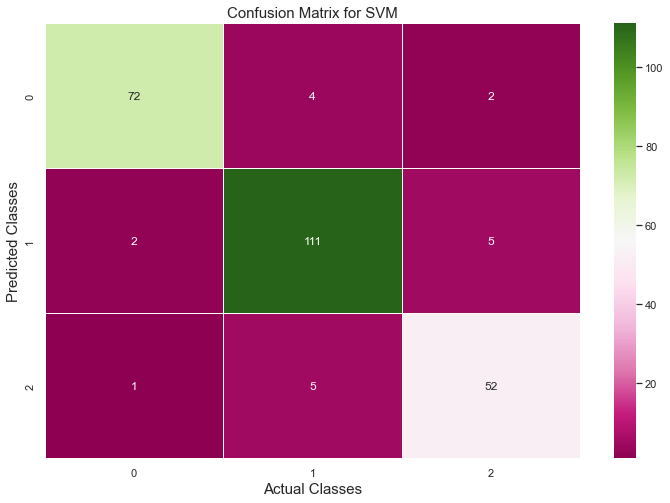

```python
#visualization of confusion matrix in the form of a heatmap
cm= confusion_matrix(y_te, sv_te_predict)
plt.figure(figsize = (12, 8))
sns.heatmap(cm, annot = True, cmap = 'PiYG', linewidths=.5, fmt = 'd')
plt.xlabel('Actual Classes', fontsize = 15)
plt.ylabel('Predicted Classes', fontsize = 15)
plt.title('Confusion Matrix for SVM', fontsize = 15);
```

```python
#printing classification report
print("Classification Report")
print(metrics.classification_report(y_te, sv_te_predict, labels=[0,1,2]))
```

```
Classification Report
              precision    recall  f1-score   support

           0       0.96      0.92      0.94        78
           1       0.93      0.94      0.93       118
           2       0.88      0.90      0.89        58

    accuracy                           0.93       254
   macro avg       0.92      0.92      0.92       254
weighted avg       0.93      0.93      0.93       254
```

```python
precision_SV_pca, recall_SV_pca, f1_score_SV_pca, support_pca = precision_recall_fscore_support(y_te, sv_te_predict,average='macro')
print('Precision Score :', '%0.2f' % precision_SV_pca)
print('Recall Score :', '%0.2f' % recall_SV_pca)
print('F1-Score:', '%0.2f' % f1_score_SV_pca)
SV_Acc_pca= accuracy_score(y_te, sv_te_predict)
print('Accuracy Score :','%0.2f' % SV_Acc_pca)
```

```
Precision Score : 0.92
Recall Score : 0.92
F1-Score: 0.92
Accuracy Score : 0.93
```

```python
modellists = []
modellists.append(['Support Vector Classifier without PCA', SV_Acc * 100, recall_SV * 100, precision_SV * 100,f1_score_SV*100])
modellists.append(['Support Vector Classifier with PCA', SV_Acc_pca* 100, recall_SV_pca * 100, precision_SV_pca * 100,f1_score_SV_pca*100])
model_df = pd.DataFrame(modellists, columns = ['Model','Accuracy Score of Test Data', 'Recall Score', 'Precision Score','F1 Score'])
model_df
```

|  | Model | Accuracy Score of Test Data | Recall Score | Precision Score | F1 Score |
| --- | --- | --- | --- | --- | --- |
| 0 | Support Vector Classifier without PCA | 98.425197 | 97.995874 | 98.588758 | 98.279124 |
| 1 | Support Vector Classifier with PCA | 92.519685 | 92.010220 | 92.211864 | 92.094616 |

## Pre-requisite

1. Only apply PCA to continuous data.
2. Make sure your data is normalized before applying PCA!!

## Advantages of PCA

1. Removes correlated features
2. Improves algorithm performance
3. Reduces overfitting
4. Improves visualisation

## Limitations of PCA

1. Independent variables become less interpretable
2. Data standardization is must before PCA
3. Information Loss

## Summary/Conclusion

Both the model gives more than 90% accuracy on the test data, However, PCA used only 6 attributes to come up with an accuracy of 90%+ where as the model with Original Data used all the variables (18 columns) to come up with 90%+ accuracy, the difference can be illustrated even better if the dataset had been cursed with dimensionality.

## The takeaway for us is that PCA feeds two birds with the one scone:

It increases the signal or the information content provided to the algorithm to build the model by transforming the existing dimensions to increase the Signal to Noise Ratio.

It helps to remove the dependency present in the data by eliminating the features that contain the same information as given by another attribute and the derived components are independent of each other.